# Reproducible Research: Peer Assessment 1

Set options (figure folder)

```r
library(knitr)
opts_chunk$set(fig.path = "figure/")
```

## Loading and preprocessing the data

```r
data <- read.csv("activity.csv", stringsAsFactors = FALSE)
```

## What is mean total number of steps taken per day?

Count total number of steps per day

```r
total_steps_per_day <- tapply(data$steps, data$date, sum, na.rm = TRUE)
```

And create a histogram for total number of steps per day

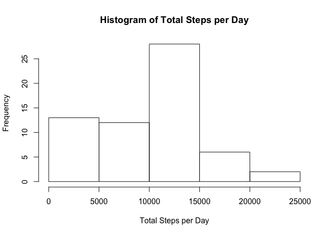

```r
hist(total_steps_per_day, xlab = "Total Steps per Day", main = "Histogram of Total Steps per Day")
```

Useful inforamtion about total steps per day

```r
summary(total_steps_per_day)
```

```
##    Min. 1st Qu.  Median    Mean 3rd Qu.    Max.
##       0    6778   10400    9354   12810   21190
```

## What is the average daily activity pattern?

Average steps by interval

```r
average_steps_by_interval <- tapply(data$steps, data$interval, mean, na.rm = TRUE)
```

And build a line chart by time interval with red line which indicates max value

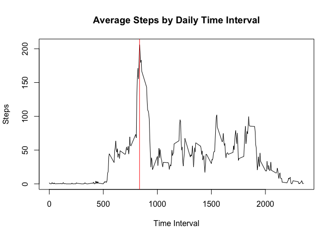

```r
plot(names(average_steps_by_interval), average_steps_by_interval, type="l", xlab = "Time Interval", ylab = "Steps", main = "Average Steps by Daily Time Interval")
abline(v = names(which.max(average_steps_by_interval)), col = "red")
```

Interval with max value corresponds to next time

```r
max_interval = which.max(average_steps_by_interval)
max_interval
```

```
## 835
## 104
```

```r
sub(pattern = "([0-9]{2})([0-9]{2})",
    replacement = "\\1:\\2",
    x = sprintf("%04s", names(max_interval)))
```

```
## [1] "08:35"
```

## Imputing missing values

```r
summary(data)
```

```
##      steps            date              interval
##  Min.   :  0.00   Length:17568       Min.   :   0.0
##  1st Qu.:  0.00   Class :character   1st Qu.: 588.8
##  Median :  0.00   Mode  :character   Median :1177.5
##  Mean   : 37.38                      Mean   :1177.5
##  3rd Qu.: 12.00                      3rd Qu.:1766.2
##  Max.   :806.00                      Max.   :2355.0
##  NA's   :2304
```

There are NA’s :2304 missing values in steps.

I will use 5-minutes mean to fill in missed values.

To replace missing values with means - create array of mean values which corresponds to original array and use **is.na()** function as index to replace missing values only

```r
mean_data <- data
mean_steps <- rep_len(average_steps_by_interval, length(data$steps))
mean_data$steps[is.na(data$steps)] <- mean_steps[is.na(data$steps)]
```

There are head-s

```r
head(data)
```

```
##   steps       date interval
## 1    NA 2012-10-01        0
## 2    NA 2012-10-01        5
## 3    NA 2012-10-01       10
## 4    NA 2012-10-01       15
## 5    NA 2012-10-01       20
## 6    NA 2012-10-01       25
```

```r
head(mean_data)
```

```
##       steps       date interval
## 1 1.7169811 2012-10-01        0
## 2 0.3396226 2012-10-01        5
## 3 0.1320755 2012-10-01       10
## 4 0.1509434 2012-10-01       15
## 5 0.0754717 2012-10-01       20
## 6 2.0943396 2012-10-01       25
```

```r
head(average_steps_by_interval)
```

```
##         0         5        10        15        20        25
## 1.7169811 0.3396226 0.1320755 0.1509434 0.0754717 2.0943396
```

and tail-s for used datasets

```r
tail(data)
```

```
##       steps       date interval
## 17563    NA 2012-11-30     2330
## 17564    NA 2012-11-30     2335
## 17565    NA 2012-11-30     2340
## 17566    NA 2012-11-30     2345
## 17567    NA 2012-11-30     2350
## 17568    NA 2012-11-30     2355
```

```r
tail(mean_data)
```

```
##           steps       date interval
## 17563 2.6037736 2012-11-30     2330
## 17564 4.6981132 2012-11-30     2335
## 17565 3.3018868 2012-11-30     2340
## 17566 0.6415094 2012-11-30     2345
## 17567 0.2264151 2012-11-30     2350
## 17568 1.0754717 2012-11-30     2355
```

```r
tail(average_steps_by_interval)
```

```
##      2330      2335      2340      2345      2350      2355
## 2.6037736 4.6981132 3.3018868 0.6415094 0.2264151 1.0754717
```

Count total number of mean steps per day

```r
total_mean_steps_per_day <- tapply(mean_data$steps, mean_data$date, sum, na.rm = TRUE)
```

And create a histogram for total number of mean steps per day

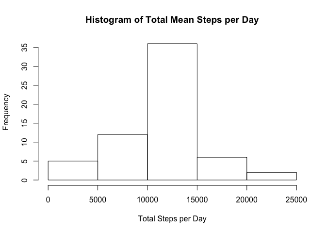

```r
hist(total_mean_steps_per_day, xlab = "Total Steps per Day", main = "Histogram of Total Mean Steps per Day")
```

Useful inforamtion about total mean steps per day

```r
summary(total_mean_steps_per_day)
```

```
##    Min. 1st Qu.  Median    Mean 3rd Qu.    Max.
##      41    9819   10770   10770   12810   21190
```

## Are there differences in activity patterns between weekdays and weekends?

Mutate date column from character to Date and add a new factor column which identified weekdays or weekends

```r
mean_data$date <- as.Date(mean_data$date)
mean_data$weekday <- factor(rep_len("weekday", length(mean_data$date)), levels = c("weekday", "weekend"));
weekdays <- weekdays(mean_data$date);
mean_data$weekday[weekdays == "Sunday" | weekdays == "Saturday"] <- "weekend"
```

Lets validate results

```r
table(mean_data$weekday)
```

```
##
## weekday weekend
##   12960    4608
```

```r
table(weekdays(mean_data$date))
```

```
##
##    Friday    Monday  Saturday    Sunday  Thursday   Tuesday Wednesday
##      2592      2592      2304      2304      2592      2592      2592
```

And finally build a plot for daily activity for weekdays and weekends, I will use ggplot2 as graphics system and dplyr for groupping

```r
library(dplyr)
```

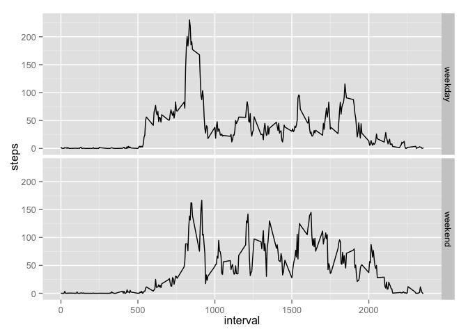

```r
library(ggplot2)

by_interval_weekday <- group_by(mean_data, interval, weekday) %>%
                       summarize(steps = mean(steps))

qplot(x = interval, y = steps, geom = "line", data = by_interval_weekday, facets = weekday ~ . )
```